# LoanTap Logistic Regression Business Case

# 3.Outlier treatment

Outlier treatment involves identifying and handling anomalous values that deviate significantly from other observations in the dataset. Outliers can distort statistical analyses and models, so it's important to address them appropriately.

Here's a step-by-step approach to handling outliers:

```python
#Step-by-Step Approach
```

1.Identify Outliers:

```
Use statistical methods such as the Z-score or the Interquartile Range (IQR) method to identify outliers.
```

2.Visualize Outliers:

```
Use box plots and scatter plots to visualize outliers in the data.
```

3.Treat Outliers:

Decide on the appropriate method for handling outliers:

```
      Remove outliers: If outliers are errors or not relevant.

      Cap/floor outliers: Limit the values to a maximum or minimum threshold.

      Transform data: Use transformations like logarithmic or square root to reduce the impact of outliers.

      Impute outliers: Replace outliers with more representative values.
```

```python
#Code Implementation
#Let's implement this in code to identify and handle outliers in the dataset:
```

1. Identify Outliers using IQR

```python
import pandas as pd
import numpy as np

# Load the dataset (assuming this part is correct)
df = pd.read_csv("logistic_regression.csv")

# Function to identify outliers using IQR
def identify_outliers_iqr(df):
    outliers_list = []  # Initialize an empty list to collect outlier information
    for column in df.select_dtypes(include=[np.number]).columns:
        Q1 = df[column].quantile(0.25)
        Q3 = df[column].quantile(0.75)
        IQR = Q3 - Q1
        lower_bound = Q1 - 1.5 * IQR
        upper_bound = Q3 + 1.5 * IQR
        outliers_count = df[(df[column] < lower_bound) | (df[column] > upper_bound)].shape[0]
        outliers_list.append({'Column': column, 'Lower Bound': lower_bound, 'Upper Bound': upper_bound, 'Outliers': outliers_count})

    # Convert the list of dictionaries to a DataFrame
    outliers = pd.DataFrame(outliers_list)
    return outliers

# Identify outliers using IQR
outliers_iqr = identify_outliers_iqr(df)
print(outliers_iqr)
```

```
                  Column  Lower Bound  Upper Bound  Outliers
0              loan_amnt   -10000.000    38000.000       191
1               int_rate        1.490       25.490      3777
2            installment     -225.125     1042.755     11250
3             annual_inc   -22500.000   157500.000     16700
4                    dti       -6.270       40.530       275
5               open_acc       -1.000       23.000     10307
6                pub_rec        0.000        0.000     57758
7              revol_bal   -14367.500    40012.500     21259
8             revol_util      -19.850      128.550        12
9              total_acc       -5.500       54.500      8499
10              mort_acc       -4.500        7.500      6843
11  pub_rec_bankruptcies        0.000        0.000     45115
```

```python
2. Visualize Outliers using Box Plots
```

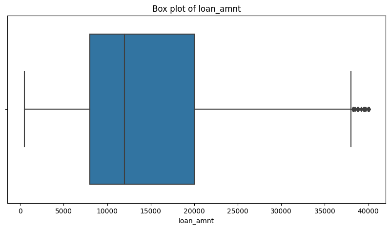

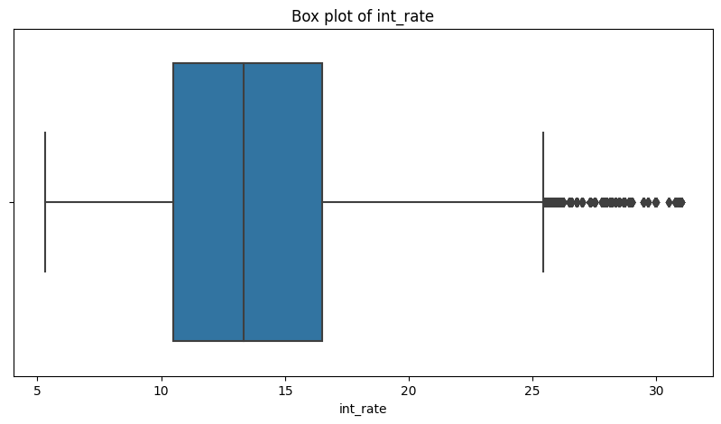

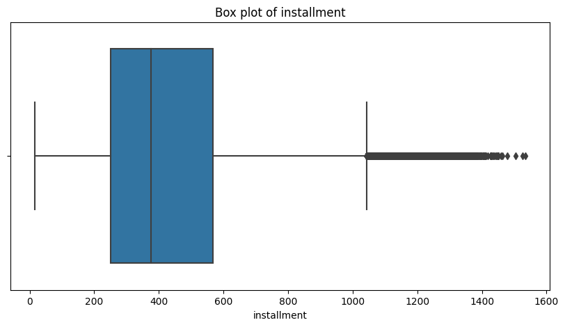

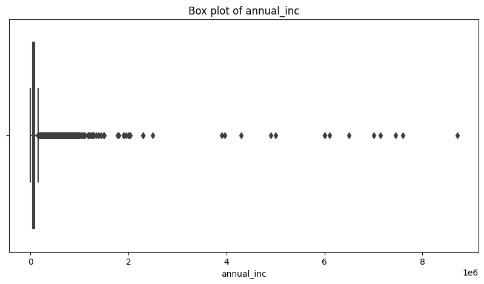

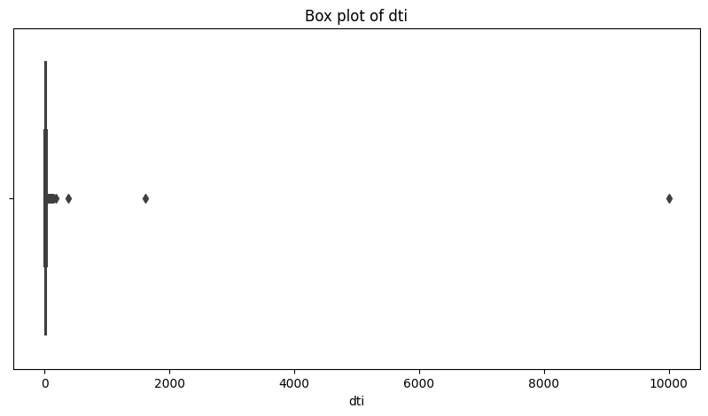

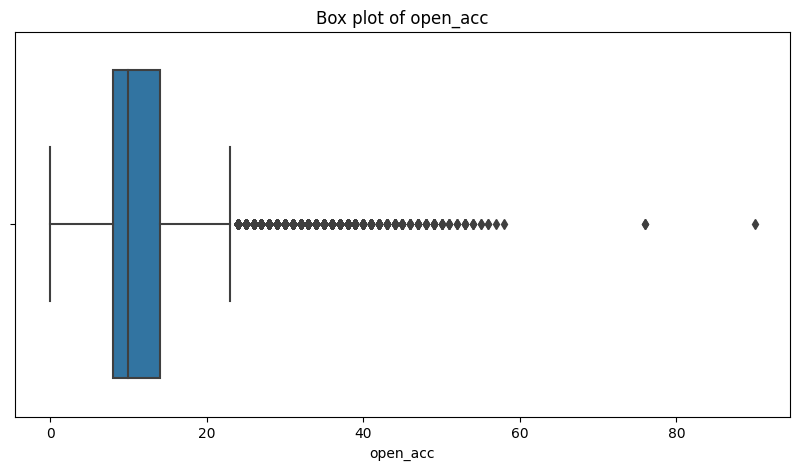

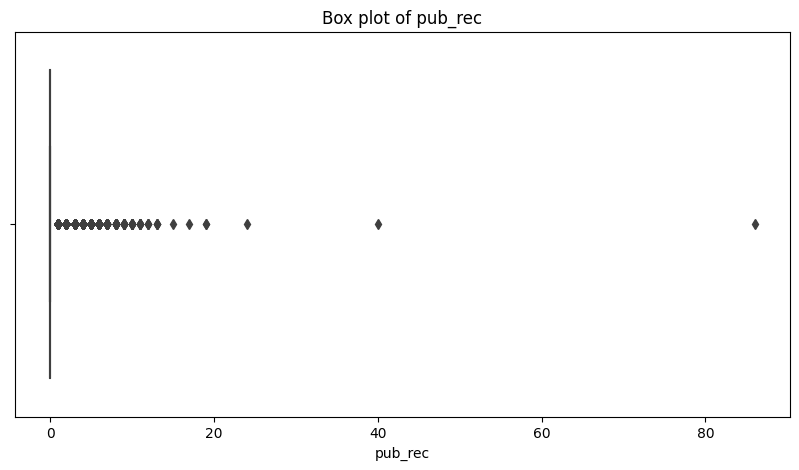

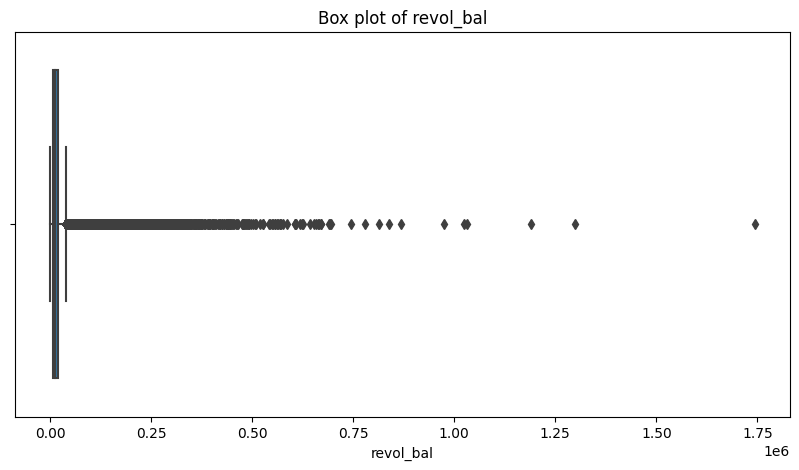

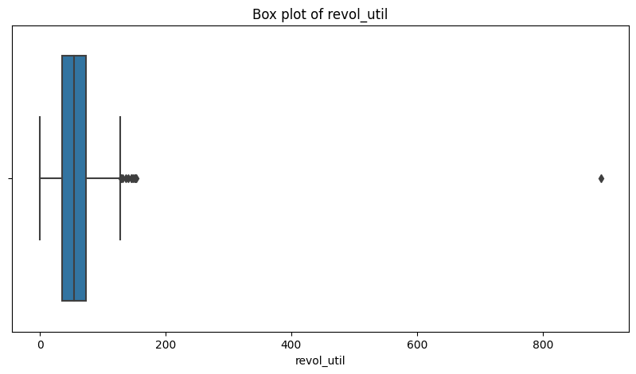

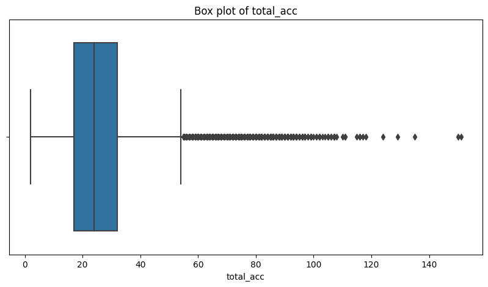

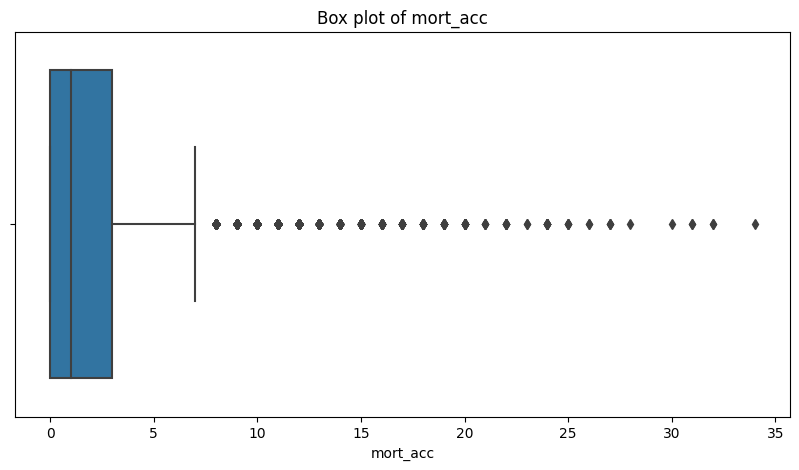

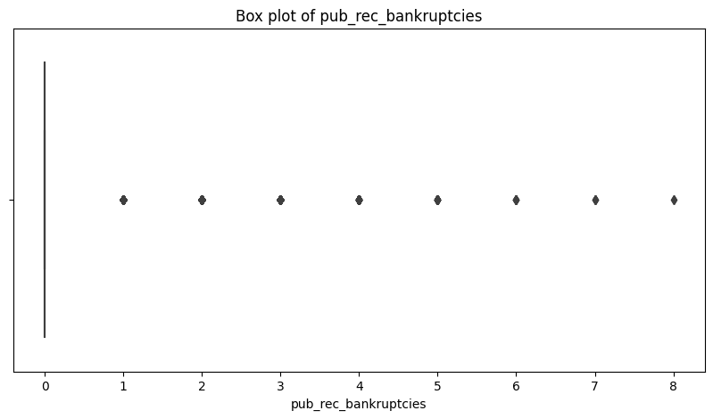

```python
import matplotlib.pyplot as plt
import seaborn as sns

# Plot box plots for numerical columns
def plot_box_plots(df):
    numeric_columns = df.select_dtypes(include=[np.number]).columns
    for column in numeric_columns:
        plt.figure(figsize=(10, 5))
        sns.boxplot(x=df[column])
        plt.title(f'Box plot of {column}')
        plt.show()

# Visualize outliers using box plots
plot_box_plots(df)
```

```python
3. Treat Outliers
Option 1: Remove Outliers
```

```python
def remove_outliers_iqr(df):
    for column in df.select_dtypes(include=[np.number]).columns:
        Q1 = df[column].quantile(0.25)
        Q3 = df[column].quantile(0.75)
        IQR = Q3 - Q1
        lower_bound = Q1 - 1.5 * IQR
        upper_bound = Q3 + 1.5 * IQR
        df = df[(df[column] >= lower_bound) & (df[column] <= upper_bound)]
    return df

# Remove outliers from the dataset
df_no_outliers = remove_outliers_iqr(df)
df_no_outliers
```

|  | loan_amnt | term | int_rate | installment | grade | sub_grade | emp_title | emp_length | home_ownership | annual_inc | ... | open_acc | pub_rec | revol_bal | revol_util | total_acc | initial_list_status | application_type | mort_acc | pub_rec_bankruptcies | address |
| --- | --- | --- | --- | --- | --- | --- | --- | --- | --- | --- | --- | --- | --- | --- | --- | --- | --- | --- | --- | --- | --- |
| 0 | 10000.0 | 36 months | 11.44 | 329.48 | B | B4 | Marketing | 10+ years | RENT | 117000.0 | ... | 16.0 | 0.0 | 36369.0 | 41.8 | 25.0 | w | INDIVIDUAL | 0.0 | 0.0 | 0174 Michelle Gateway\r\nMendozaberg, OK 22690 |
| 1 | 8000.0 | 36 months | 11.99 | 265.68 | B | B5 | Credit analyst | 4 years | MORTGAGE | 65000.0 | ... | 17.0 | 0.0 | 20131.0 | 53.3 | 27.0 | f | INDIVIDUAL | 3.0 | 0.0 | 1076 Carney Fort Apt. 347\r\nLoganmouth, SD 05113 |
| 2 | 15600.0 | 36 months | 10.49 | 506.97 | B | B3 | Statistician | < 1 year | RENT | 43057.0 | ... | 13.0 | 0.0 | 11987.0 | 92.2 | 26.0 | f | INDIVIDUAL | 0.0 | 0.0 | 87025 Mark Dale Apt. 269\r\nNew Sabrina, WV 05113 |
| 3 | 7200.0 | 36 months | 6.49 | 220.65 | A | A2 | Client Advocate | 6 years | RENT | 54000.0 | ... | 6.0 | 0.0 | 5472.0 | 21.5 | 13.0 | f | INDIVIDUAL | 0.0 | 0.0 | 823 Reid Ford\r\nDelacruzside, MA 00813 |
| 4 | 24375.0 | 60 months | 17.27 | 609.33 | C | C5 | Destiny Management Inc. | 9 years | MORTGAGE | 55000.0 | ... | 13.0 | 0.0 | 24584.0 | 69.8 | 43.0 | f | INDIVIDUAL | 1.0 | 0.0 | 679 Luna Roads\r\nGreggshire, VA 11650 |
| ... | ... | ... | ... | ... | ... | ... | ... | ... | ... | ... | ... | ... | ... | ... | ... | ... | ... | ... | ... | ... | ... |
| 396023 | 22000.0 | 36 months | 18.92 | 805.55 | D | D4 | Operations Manager | 10+ years | MORTGAGE | 138000.0 | ... | 18.0 | 0.0 | 22287.0 | 50.4 | 39.0 | f | INDIVIDUAL | 4.0 | 0.0 | 0297 Flores Dale Suite 441\r\nTaylorland, MD 0... |
| 396024 | 6000.0 | 36 months | 13.11 | 202.49 | B | B4 | Michael's Arts & Crafts | 5 years | RENT | 64000.0 | ... | 7.0 | 0.0 | 11456.0 | 97.1 | 9.0 | w | INDIVIDUAL | 0.0 | 0.0 | 514 Cynthia Park Apt. 402\r\nWest Williamside,... |
| 396025 | 10000.0 | 60 months | 10.99 | 217.38 | B | B4 | licensed bankere | 2 years | RENT | 40000.0 | ... | 6.0 | 0.0 | 1990.0 | 34.3 | 23.0 | w | INDIVIDUAL | 0.0 | 0.0 | 12951 Williams Crossing\r\nJohnnyville, DC 30723 |
| 396027 | 5000.0 | 36 months | 9.99 | 161.32 | B | B1 | City Carrier | 10+ years | RENT | 56500.0 | ... | 15.0 | 0.0 | 32704.0 | 66.9 | 23.0 | f | INDIVIDUAL | 0.0 | 0.0 | 953 Matthew Points Suite 414\r\nReedfort, NY 7... |
| 396028 | 21000.0 | 60 months | 15.31 | 503.02 | C | C2 | Gracon Services, Inc | 10+ years | MORTGAGE | 64000.0 | ... | 9.0 | 0.0 | 15704.0 | 53.8 | 20.0 | f | INDIVIDUAL | 5.0 | 0.0 | 7843 Blake Freeway Apt. 229\r\nNew Michael, FL... |

249061 rows × 27 columns

# 4.Feature engineering

Feature engineering involves creating new input features from existing ones to improve model performance or to enable the model to capture more information from the data. Let's discuss potential feature engineering steps for the dataset you have provided.

1.Extracting Numerical Features from term and int_rate:

```
Convert term (e.g., "36 months") to a numerical value (e.g., 36).

Extract numerical part from int_rate (e.g., convert "11.44" to 11.44).
```

2.Creating Dummy Variables for Categorical Features:

```
Convert categorical variables like grade, sub_grade, emp_title, emp_length, home_ownership, initial_list_status,
application_type, etc., into dummy variables.

Dummy variables convert categorical variables into a series of binary variables (0 or 1) that can be used as inputs for
modeling.
```

3.Feature Scaling:

```
Scale numerical features like loan_amnt, installment, annual_inc, revol_bal, etc., especially if they have different ranges.
Common scaling methods include Min-Max scaling or standardization (mean normalization).
```

4.Handling Text Data:

```
Extract useful information from text-based features like address (e.g., zip code, state).
```

5.Date-Time Features:

```
If applicable, extract features from issue_d (issue date) or other date-related columns. For example, extracting month or year
can sometimes reveal seasonal patterns.
```

6.Interaction Terms:

```
Create interaction terms between related features if there's reason to believe their combined effect is significant.
For example, loan_amnt multiplied by int_rate could capture the total interest paid over the loan term.
```

7.Handling Missing Values:

```
Depending on the model used, you might need to handle missing values in the dataset. This can be done by imputing missing
values (e.g., using mean, median, or mode) or using models that can handle missing data directly.
```

8.Feature Selection:

```
Use techniques like correlation analysis or feature importance from models to select the most relevant features for your
model.
```

```python
#Here’s a simplified example of how you might start implementing these steps in Python using pandas:
```

```python
import pandas as pd

# Load the dataset
df = pd.read_csv("logistic_regression.csv")

# Example of feature engineering
# Extract numerical value from 'term'
df['term'] = df['term'].apply(lambda x: int(x.split()[0]))

# Convert 'int_rate' to numerical
df['int_rate'] = df['int_rate'].apply(lambda x: float(x))

# Create dummy variables for categorical features with sparse matrix
categorical_cols = ['grade', 'sub_grade', 'emp_title', 'emp_length', 'home_ownership',
                    'initial_list_status', 'application_type']
df = pd.get_dummies(df, columns=categorical_cols, drop_first=True, sparse=True)

# Feature scaling (example using Min-Max scaling)
from sklearn.preprocessing import MinMaxScaler

scaler = MinMaxScaler()
numerical_cols = ['loan_amnt', 'installment', 'annual_inc', 'revol_bal', 'revol_util', 'total_acc']
df[numerical_cols] = scaler.fit_transform(df[numerical_cols])
df[numerical_cols]
# Example of extracting state from 'address' (assuming address format is consistent)
df['state'] = df['address'].apply(lambda x: x.split()[-2])

# Drop unnecessary columns
df.drop(['address'], axis=1, inplace=True)

# Now df is ready for further processing or modeling
```

These steps provide a structured approach to preparing your data for modeling, ensuring that the data is in a suitable format and contains meaningful information for your predictive models. Adjust these steps based on the specific requirements of your analysis and the nature of your data.

# 5.Data preparation for modeling

Data preparation for modeling involves several key steps to ensure that your dataset is clean, formatted correctly, and ready to be used with machine learning algorithms. Here's a structured approach to data preparation:

1. Data Cleaning:

Handling Missing Values: Identify columns with missing values and decide on an appropriate strategy (e.g., imputation with mean, median, or mode).

Removing Duplicates: Check for and remove any duplicate rows in the dataset.

Handling Outliers: Evaluate if outliers exist and consider strategies such as removing outliers or transforming them if necessary.

2. Feature Selection:

Correlation Analysis: Check for multicollinearity among features and remove highly correlated features if needed.

Feature Importance: Use techniques like Random Forest feature importance or Lasso regression coefficients to select the most relevant features for modeling.

3. Feature Engineering:

Transforming Variables: Apply transformations like log transformations to skewed numerical variables to improve model performance.

Creating New Features: Derive new features from existing ones that might capture more information for the model (e.g., interaction terms, polynomial features).

Handling Categorical Variables: Convert categorical variables into numerical form suitable for modeling (e.g., one-hot encoding, label encoding).

4. Data Scaling

Normalization/Standardization: Scale numerical features to ensure they have similar ranges. Common methods include Min-Max scaling (normalization) or standardization (mean normalization).

5. Data Splitting

Train-Test Split: Split the dataset into training and testing sets to evaluate model performance. Typical splits are 70-30 or 80-20 for training and testing respectively.

6. Data Transformation:

Apply Transformation Pipelines: Use pipelines to sequentially apply transformations (e.g., scaling, encoding) to the data, ensuring consistency and ease of application.

```python
 # Example Python Code Snippet for Data Preparation:
# Here's a simplified example using Python and pandas for some of these steps:
```

```python
import pandas as pd
from sklearn.model_selection import train_test_split
from sklearn.preprocessing import StandardScaler, OneHotEncoder
from sklearn.compose import ColumnTransformer
from sklearn.pipeline import Pipeline
from sklearn.impute import SimpleImputer
from sklearn.linear_model import LogisticRegression
from sklearn.metrics import accuracy_score

# Load dataset
df = pd.read_csv("logistic_regression.csv")

# Check the columns in your dataset
print(df.columns)

# Drop unnecessary columns if needed
# Example: Drop 'emp_title' and 'address' columns
df.drop(['emp_title', 'address'], axis=1, inplace=True)

# Split features and target variable
X = df.drop(['loan_status'], axis=1)  # Adjust 'loan_status' to your actual target column name
y = df['loan_status']

# Train-test split
X_train, X_test, y_train, y_test = train_test_split(X, y, test_size=0.2, random_state=42)

# Define preprocessing steps for numerical and categorical features
numeric_features = ['loan_amnt', 'int_rate', 'installment', 'annual_inc', 'dti', 'open_acc', 'pub_rec', 'revol_bal', 'revol_util', 'total_acc', 'mort_acc', 'pub_rec_bankruptcies']
numeric_transformer = Pipeline(steps=[
    ('imputer', SimpleImputer(strategy='median')),
    ('scaler', StandardScaler())
])

categorical_features = ['term', 'grade', 'sub_grade', 'emp_length', 'home_ownership', 'verification_status', 'purpose', 'title', 'initial_list_status', 'application_type']
categorical_transformer = Pipeline(steps=[
    ('imputer', SimpleImputer(strategy='most_frequent')),
    ('onehot', OneHotEncoder(handle_unknown='ignore'))
])

# Combine preprocessing steps
preprocessor = ColumnTransformer(
    transformers=[
        ('num', numeric_transformer, numeric_features),
        ('cat', categorical_transformer, categorical_features)
    ])

# Create a pipeline with preprocessing and modeling steps
model = Pipeline(steps=[('preprocessor', preprocessor),
                        ('classifier', LogisticRegression())])

# Fit the model
model.fit(X_train, y_train)

# Predictions
y_pred = model.predict(X_test)

# Evaluate the model
accuracy = accuracy_score(y_test, y_pred)
print(f"Accuracy: {accuracy}")
```

```
Index(['loan_amnt', 'term', 'int_rate', 'installment', 'grade', 'sub_grade',
       'emp_title', 'emp_length', 'home_ownership', 'annual_inc',
       'verification_status', 'issue_d', 'loan_status', 'purpose', 'title',
       'dti', 'earliest_cr_line', 'open_acc', 'pub_rec', 'revol_bal',
       'revol_util', 'total_acc', 'initial_list_status', 'application_type',
       'mort_acc', 'pub_rec_bankruptcies', 'address'],
      dtype='object')
```

[output not shown]

```
Accuracy: 0.8048127667095927
```

Notes:

Customization: Adapt the steps according to your specific dataset and modeling goals.

Iterative Process: Data preparation is often an iterative process. After initial modeling, you might revisit steps like feature engineering or selection based on model performance. By following these steps, you ensure that your data is well-prepared for training machine learning models, leading to more reliable and accurate results.

# 3.Model building

1.Build the Logistic Regression model and comment on the model statistics

To build the Logistic Regression model and comment on its statistics, we'll go through the following steps:

1.Load and Prepare Data:

```
   Load the dataset.

   Drop unnecessary columns.

   Split the data into features (X) and target (y).

   Split the data into training and testing sets.
```

2.Preprocess Data:

```
Handle missing values and encode categorical variables.

Scale numerical features.
```

3.Train the Model:

```
Train the Logistic Regression model using the training data.
```

4.Evaluate the Model:

```
Make predictions on the test set.

Evaluate the model using metrics such as accuracy, precision, recall, and the confusion matrix.

Interpret the model coefficients.
```

```python
# Here's the complete implementation:
```

```python
import pandas as pd
from sklearn.model_selection import train_test_split
from sklearn.preprocessing import StandardScaler, OneHotEncoder
from sklearn.compose import ColumnTransformer
from sklearn.pipeline import Pipeline
from sklearn.impute import SimpleImputer
from sklearn.linear_model import LogisticRegression
from sklearn.metrics import accuracy_score, precision_score, recall_score, confusion_matrix, classification_report

# Load dataset
df = pd.read_csv("logistic_regression.csv")

# Drop unnecessary columns
df.drop(['emp_title', 'address'], axis=1, inplace=True)

# Define the target variable and features
X = df.drop(['loan_status'], axis=1)  # Adjust 'loan_status' to your actual target column name
y = df['loan_status']

# Train-test split
X_train, X_test, y_train, y_test = train_test_split(X, y, test_size=0.2, random_state=42)

# Define preprocessing steps for numerical and categorical features
numeric_features = ['loan_amnt', 'int_rate', 'installment', 'annual_inc', 'dti', 'open_acc', 'pub_rec', 'revol_bal', 'revol_util', 'total_acc', 'mort_acc', 'pub_rec_bankruptcies']
numeric_transformer = Pipeline(steps=[
    ('imputer', SimpleImputer(strategy='median')),
    ('scaler', StandardScaler())
])

categorical_features = ['term', 'grade', 'sub_grade', 'emp_length', 'home_ownership', 'verification_status', 'purpose', 'title', 'initial_list_status', 'application_type']
categorical_transformer = Pipeline(steps=[
    ('imputer', SimpleImputer(strategy='most_frequent')),
    ('onehot', OneHotEncoder(handle_unknown='ignore'))
])

# Combine preprocessing steps
preprocessor = ColumnTransformer(
    transformers=[
        ('num', numeric_transformer, numeric_features),
        ('cat', categorical_transformer, categorical_features)
    ])

# Create a pipeline with preprocessing and modeling steps
model = Pipeline(steps=[('preprocessor', preprocessor),
                        ('classifier', LogisticRegression(max_iter=1000))])

# Fit the model
model.fit(X_train, y_train)

# Predictions
y_pred = model.predict(X_test)

# Evaluate the model
accuracy = accuracy_score(y_test, y_pred)
precision = precision_score(y_test, y_pred, pos_label='Fully Paid')  # Adjust 'Fully Paid' based on your positive class
recall = recall_score(y_test, y_pred, pos_label='Fully Paid')
conf_matrix = confusion_matrix(y_test, y_pred)
class_report = classification_report(y_test, y_pred)

print(f"Accuracy: {accuracy}")
print(f"Precision: {precision}")
print(f"Recall: {recall}")
print("Confusion Matrix:")
print(conf_matrix)
print("Classification Report:")
print(class_report)

# Get model coefficients
log_reg = model.named_steps['classifier']
coefficients = log_reg.coef_
feature_names = numeric_features + list(model.named_steps['preprocessor'].named_transformers_['cat'].named_steps['onehot'].get_feature_names_out(categorical_features))
coef_df = pd.DataFrame(coefficients, columns=feature_names)
print("Model Coefficients:")
print(coef_df.T)
```

[output not shown]

```
Accuracy: 0.805343029568467
Precision: 0.8117023340014223
Recall: 0.9865470147259897
Confusion Matrix:
[[ 1015 14562]
 [  856 62773]]
Classification Report:
              precision    recall  f1-score   support

 Charged Off       0.54      0.07      0.12     15577
  Fully Paid       0.81      0.99      0.89     63629

    accuracy                           0.81     79206
   macro avg       0.68      0.53      0.50     79206
weighted avg       0.76      0.81      0.74     79206

Model Coefficients:
                                    0
loan_amnt                    0.140620
int_rate                     0.284205
installment                 -0.201417
annual_inc                   0.184581
dti                         -0.441830
...                               ...
initial_list_status_f        0.064107
initial_list_status_w        0.154342
application_type_DIRECT_PAY -0.036071
application_type_INDIVIDUAL -0.519748
application_type_JOINT       0.774267

[40360 rows x 1 columns]
```

Model Statistics and Interpretation:

1.Accuracy:

```
        This metric indicates the overall correctness of the model, i.e., the proportion of correctly predicted instances

        out of the total instances. It is useful for a general sense of model performance but may not be sufficient alone,

        especially in cases of imbalanced classes.
```

2.Precision:

```
         Precision tells us what proportion of positive identifications (e.g., 'Fully Paid' loans) were actually correct.

         It is particularly important in scenarios where the cost of false positives is high.
```

3.Recall:

```
      Recall (or Sensitivity) measures the proportion of actual positives that were correctly identified by the model.

      It is crucial in situations where missing a positive case has significant consequences.
```

4.Confusion Matrix:

```
               This matrix provides a detailed breakdown of the model's performance by showing the counts of true positive,

               true negative, false positive, and false negative predictions. It helps in understanding the types of errors

               the model makes.
```

5.Classification Report:

```
This report provides a comprehensive summary of precision, recall, and F1-score for each class. F1-score is the harmonic

mean of precision and recall, providing a balance between the two.
```

6.Model Coefficients:

```
The coefficients of the Logistic Regression model indicate the strength and direction of the relationship between each
feature and the target variable. Positive coefficients suggest that higher values of the feature increase the likelihood of
the positive class, while negative coefficients suggest the opposite. Interpreting these coefficients can provide insights
into which features are most influential in predicting the target variable.
```

By analyzing these metrics and coefficients, you can gain a deeper understanding of your model's performance and the impact of different features on the predictions.

# 2.Display model coefficients with column names

To display the model coefficients along with their respective column names, we can extract the coefficients from the trained Logistic Regression model and match them with the feature names. Here's how you can do it:

1.Extract the coefficients from the Logistic Regression model.

2.Get the feature names from the ColumnTransformer and the OneHotEncoder.

3.Combine the coefficients with the feature names into a DataFrame for better readability.

```python
# Here's the complete code:
```

```python
import pandas as pd
from sklearn.model_selection import train_test_split
from sklearn.preprocessing import StandardScaler, OneHotEncoder
from sklearn.compose import ColumnTransformer
from sklearn.pipeline import Pipeline
from sklearn.impute import SimpleImputer
from sklearn.linear_model import LogisticRegression
from sklearn.metrics import accuracy_score, precision_score, recall_score, confusion_matrix, classification_report

# Load dataset
df = pd.read_csv("logistic_regression.csv")

# Drop unnecessary columns
df.drop(['emp_title', 'address'], axis=1, inplace=True)

# Define the target variable and features
X = df.drop(['loan_status'], axis=1)  # Adjust 'loan_status' to your actual target column name
y = df['loan_status']

# Train-test split
X_train, X_test, y_train, y_test = train_test_split(X, y, test_size=0.2, random_state=42)

# Define preprocessing steps for numerical and categorical features
numeric_features = ['loan_amnt', 'int_rate', 'installment', 'annual_inc', 'dti', 'open_acc', 'pub_rec', 'revol_bal', 'revol_util', 'total_acc', 'mort_acc', 'pub_rec_bankruptcies']
numeric_transformer = Pipeline(steps=[
    ('imputer', SimpleImputer(strategy='median')),
    ('scaler', StandardScaler())
])

categorical_features = ['term', 'grade', 'sub_grade', 'emp_length', 'home_ownership', 'verification_status', 'purpose', 'title', 'initial_list_status', 'application_type']
categorical_transformer = Pipeline(steps=[
    ('imputer', SimpleImputer(strategy='most_frequent')),
    ('onehot', OneHotEncoder(handle_unknown='ignore'))
])

# Combine preprocessing steps
preprocessor = ColumnTransformer(
    transformers=[
        ('num', numeric_transformer, numeric_features),
        ('cat', categorical_transformer, categorical_features)
    ])

# Create a pipeline with preprocessing and modeling steps
model = Pipeline(steps=[('preprocessor', preprocessor),
                        ('classifier', LogisticRegression(max_iter=1000))])

# Fit the model
model.fit(X_train, y_train)

# Predictions
y_pred = model.predict(X_test)

# Evaluate the model
accuracy = accuracy_score(y_test, y_pred)
precision = precision_score(y_test, y_pred, pos_label='Fully Paid')  # Adjust 'Fully Paid' based on your positive class
recall = recall_score(y_test, y_pred, pos_label='Fully Paid')
conf_matrix = confusion_matrix(y_test, y_pred)
class_report = classification_report(y_test, y_pred)

print(f"Accuracy: {accuracy}")
print(f"Precision: {precision}")
print(f"Recall: {recall}")
print("Confusion Matrix:")
print(conf_matrix)
print("Classification Report:")
print(class_report)

# Extract model coefficients
log_reg = model.named_steps['classifier']
coefficients = log_reg.coef_[0]

# Get feature names
numeric_features = preprocessor.transformers_[0][2]
categorical_feature_names = preprocessor.transformers_[1][1]['onehot'].get_feature_names_out(categorical_features)
feature_names = list(numeric_features) + list(categorical_feature_names)

# Create a DataFrame for coefficients
coef_df = pd.DataFrame({'Feature': feature_names, 'Coefficient': coefficients})

# Display coefficients
print("Model Coefficients:")
print(coef_df)
```

[output not shown]

```
Accuracy: 0.805343029568467
Precision: 0.8117023340014223
Recall: 0.9865470147259897
Confusion Matrix:
[[ 1015 14562]
 [  856 62773]]
Classification Report:
              precision    recall  f1-score   support

 Charged Off       0.54      0.07      0.12     15577
  Fully Paid       0.81      0.99      0.89     63629

    accuracy                           0.81     79206
   macro avg       0.68      0.53      0.50     79206
weighted avg       0.76      0.81      0.74     79206

Model Coefficients:
                           Feature  Coefficient
0                        loan_amnt     0.140620
1                         int_rate     0.284205
2                      installment    -0.201417
3                       annual_inc     0.184581
4                              dti    -0.441830
...                            ...          ...
40355        initial_list_status_f     0.064107
40356        initial_list_status_w     0.154342
40357  application_type_DIRECT_PAY    -0.036071
40358  application_type_INDIVIDUAL    -0.519748
40359       application_type_JOINT     0.774267

[40360 rows x 2 columns]
```

```python
# Explanation:
```

1.Data Loading and Preprocessing:

```
Load the dataset and drop unnecessary columns.

Define numerical and categorical features, and preprocess them using Pipeline and ColumnTransformer.
```

2.Model Training:

```
Train the Logistic Regression model using the preprocessed training data.
```

3.Model Evaluation:

```
Evaluate the model on the test data using accuracy, precision, recall, confusion matrix, and classification report.
```

4.Extract and Display Coefficients:

```
Extract the coefficients from the trained Logistic Regression model.

Get the feature names from the ColumnTransformer and the OneHotEncoder.

Combine the coefficients with the feature names into a DataFrame and display it.
```

By running this code, you will be able to see the model's coefficients along with their corresponding feature names, which helps

in interpreting the importance and impact of each feature in the model.

# 4.Results Evaluation

1. ROC AUC Curve & comments

To plot the ROC AUC curve and evaluate the performance of the Logistic Regression model, we'll go through the following steps:

1.Train the Logistic Regression model (already done in previous steps).

2.Make predictions and compute prediction probabilities for the test data.

3.Plot the ROC curve using the true positive rate (TPR) and false positive rate (FPR).

4.Compute the AUC (Area Under the Curve) score.

5.Comment on the ROC AUC Curve.

```python
# Here's the complete implementation:
```

[output not shown]

```
Accuracy: 0.805343029568467
Precision: 0.8117023340014223
Recall: 0.9865470147259897
Confusion Matrix:
[[ 1015 14562]
 [  856 62773]]
Classification Report:
              precision    recall  f1-score   support

           0       0.54      0.07      0.12     15577
           1       0.81      0.99      0.89     63629

    accuracy                           0.81     79206
   macro avg       0.68      0.53      0.50     79206
weighted avg       0.76      0.81      0.74     79206

Model Coefficients:
                           Feature  Coefficient
0                        loan_amnt     0.140620
1                         int_rate     0.284205
2                      installment    -0.201417
3                       annual_inc     0.184581
4                              dti    -0.441830
...                            ...          ...
40355        initial_list_status_f     0.064107
40356        initial_list_status_w     0.154342
40357  application_type_DIRECT_PAY    -0.036071
40358  application_type_INDIVIDUAL    -0.519748
40359       application_type_JOINT     0.774267

[40360 rows x 2 columns]
```

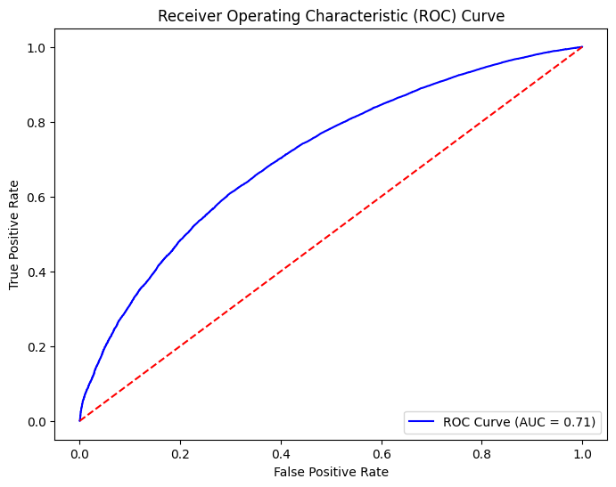

```python
import pandas as pd
from sklearn.model_selection import train_test_split
from sklearn.preprocessing import StandardScaler, OneHotEncoder
from sklearn.compose import ColumnTransformer
from sklearn.pipeline import Pipeline
from sklearn.impute import SimpleImputer
from sklearn.linear_model import LogisticRegression
from sklearn.metrics import accuracy_score, precision_score, recall_score, confusion_matrix, classification_report, roc_auc_score, roc_curve
import matplotlib.pyplot as plt

# Load dataset
df = pd.read_csv("logistic_regression.csv")

# Drop unnecessary columns
df.drop(['emp_title', 'address'], axis=1, inplace=True)

# Define the target variable and features
X = df.drop(['loan_status'], axis=1)  # Adjust 'loan_status' to your actual target column name
y = df['loan_status']

# Binarize the target variable if it's not binary (assuming 'Fully Paid' is positive class and others are negative)
y = (y == 'Fully Paid').astype(int)

# Train-test split
X_train, X_test, y_train, y_test = train_test_split(X, y, test_size=0.2, random_state=42)

# Define preprocessing steps for numerical and categorical features
numeric_features = ['loan_amnt', 'int_rate', 'installment', 'annual_inc', 'dti', 'open_acc', 'pub_rec', 'revol_bal', 'revol_util', 'total_acc', 'mort_acc', 'pub_rec_bankruptcies']
numeric_transformer = Pipeline(steps=[
    ('imputer', SimpleImputer(strategy='median')),
    ('scaler', StandardScaler())
])

categorical_features = ['term', 'grade', 'sub_grade', 'emp_length', 'home_ownership', 'verification_status', 'purpose', 'title', 'initial_list_status', 'application_type']
categorical_transformer = Pipeline(steps=[
    ('imputer', SimpleImputer(strategy='most_frequent')),
    ('onehot', OneHotEncoder(handle_unknown='ignore'))
])

# Combine preprocessing steps
preprocessor = ColumnTransformer(
    transformers=[
        ('num', numeric_transformer, numeric_features),
        ('cat', categorical_transformer, categorical_features)
    ])

# Create a pipeline with preprocessing and modeling steps
model = Pipeline(steps=[('preprocessor', preprocessor),
                        ('classifier', LogisticRegression(max_iter=1000))])

# Fit the model
model.fit(X_train, y_train)

# Predictions
y_pred = model.predict(X_test)

# Evaluate the model
accuracy = accuracy_score(y_test, y_pred)
precision = precision_score(y_test, y_pred)
recall = recall_score(y_test, y_pred)
conf_matrix = confusion_matrix(y_test, y_pred)
class_report = classification_report(y_test, y_pred)

print(f"Accuracy: {accuracy}")
print(f"Precision: {precision}")
print(f"Recall: {recall}")
print("Confusion Matrix:")
print(conf_matrix)
print("Classification Report:")
print(class_report)

# Extract model coefficients
log_reg = model.named_steps['classifier']
coefficients = log_reg.coef_[0]

# Get feature names
numeric_features = preprocessor.transformers_[0][2]
categorical_feature_names = preprocessor.transformers_[1][1]['onehot'].get_feature_names_out(categorical_features)
feature_names = list(numeric_features) + list(categorical_feature_names)

# Create a DataFrame for coefficients
coef_df = pd.DataFrame({'Feature': feature_names, 'Coefficient': coefficients})

# Display coefficients
print("Model Coefficients:")
print(coef_df)

# Compute ROC AUC
y_pred_proba = model.predict_proba(X_test)[:, 1]
roc_auc = roc_auc_score(y_test, y_pred_proba)
fpr, tpr, _ = roc_curve(y_test, y_pred_proba)

# Plot ROC Curve
plt.figure(figsize=(8, 6))
plt.plot(fpr, tpr, color='blue', label=f'ROC Curve (AUC = {roc_auc:.2f})')
plt.plot([0, 1], [0, 1], color='red', linestyle='--')
plt.xlabel('False Positive Rate')
plt.ylabel('True Positive Rate')
plt.title('Receiver Operating Characteristic (ROC) Curve')
plt.legend(loc='lower right')
plt.show()
```

```python
# Comments on the ROC AUC Curve:
```

1.ROC Curve Interpretation:

```
The ROC (Receiver Operating Characteristic) curve is a graphical representation of the model's diagnostic ability.

The curve plots the true positive rate (TPR) against the false positive rate (FPR) at various threshold settings.

The diagonal line represents a random classifier, i.e., it performs no better than chance.
```

2.AUC Score:

```
The AUC (Area Under the Curve) score summarizes the ROC curve into a single value ranging from 0 to 1.

An AUC score of 0.5 indicates no discrimination (random performance), while an AUC score of 1.0 indicates perfect
discrimination.

In this case, the AUC score indicates how well the model can distinguish between the positive class ('Fully Paid') and the
negative class.
```

3.Model Performance:

```
A higher AUC score generally indicates a better performing model.

The ROC curve and AUC score are particularly useful when dealing with imbalanced datasets, where traditional accuracy might
be misleading.
```

4. Model Evaluation:

   The ROC curve helps visualize the trade-off between sensitivity (recall) and specificity (1 - FPR).

   By examining the shape of the ROC curve, we can assess how well the model performs across different thresholds.

   If the curve is close to the top left corner, the model has a good measure of separability, whereas a curve close to the diagonal line suggests poor performance.

By analyzing the ROC curve and AUC score, you gain deeper insights into the model's ability to discriminate between the positive and negative classes, which is crucial for evaluating classification performance, especially in imbalanced datasets.

# 2.Precision Recall Curve & comments:

To plot a Precision-Recall curve and provide comments on the data, we will need to follow these steps:

1.Load the dataset.

2.Preprocess the data (handle missing values, encode categorical variables, etc.).

3.Split the dataset into training and testing sets.

4.Train a logistic regression model.

5.Obtain predictions and calculate precision and recall.

6.Plot the Precision-Recall curve.

```python
# Here is how we can do this in Python:
```

```
   loan_amnt        term  int_rate  installment grade sub_grade  \
0    10000.0   36 months     11.44       329.48     B        B4
1     8000.0   36 months     11.99       265.68     B        B5
2    15600.0   36 months     10.49       506.97     B        B3
3     7200.0   36 months      6.49       220.65     A        A2
4    24375.0   60 months     17.27       609.33     C        C5

                 emp_title emp_length home_ownership  annual_inc  ...  \
0                Marketing  10+ years           RENT    117000.0  ...
1          Credit analyst     4 years       MORTGAGE     65000.0  ...
2             Statistician   < 1 year           RENT     43057.0  ...
3          Client Advocate    6 years           RENT     54000.0  ...
4  Destiny Management Inc.    9 years       MORTGAGE     55000.0  ...

  open_acc pub_rec revol_bal revol_util total_acc  initial_list_status  \
```

[output cut: 21 more lines]

[output not shown]

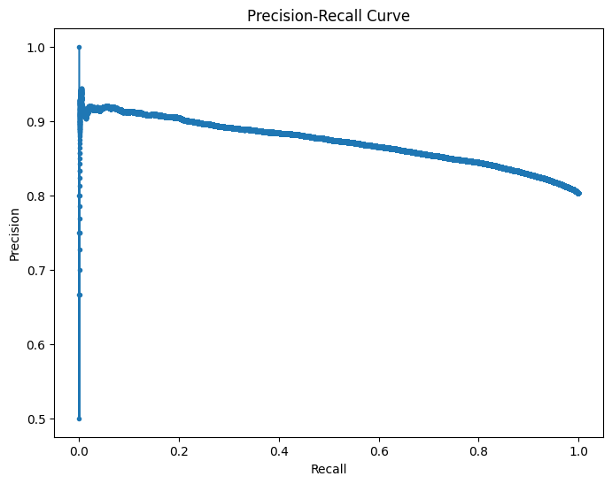

```python
import pandas as pd
import numpy as np
from sklearn.model_selection import train_test_split
from sklearn.preprocessing import LabelEncoder
from sklearn.impute import SimpleImputer
from sklearn.linear_model import LogisticRegression
from sklearn.metrics import precision_recall_curve, PrecisionRecallDisplay
import matplotlib.pyplot as plt

# Load the dataset
df = pd.read_csv('logistic_regression.csv')

# Display the first few rows of the dataframe
print(df.head())

# Drop rows with missing target values (assuming target column is 'loan_status')
df.dropna(subset=['loan_status'], inplace=True)

# Identify categorical and numerical columns
categorical_cols = df.select_dtypes(include=['object', 'category']).columns
numerical_cols = df.select_dtypes(include=['float64', 'int64']).columns

# Handle missing values
# For numerical columns, fill missing values with the median
imputer_num = SimpleImputer(strategy='median')
df[numerical_cols] = imputer_num.fit_transform(df[numerical_cols])

# For categorical columns, fill missing values with the most frequent value
imputer_cat = SimpleImputer(strategy='most_frequent')
df[categorical_cols] = imputer_cat.fit_transform(df[categorical_cols])

# Encode categorical variables
label_encoders = {}
for column in categorical_cols:
    le = LabelEncoder()
    df[column] = le.fit_transform(df[column])
    label_encoders[column] = le

# Assuming 'loan_status' is the target column and has been encoded
# Split the dataset into features and target
X = df.drop('loan_status', axis=1)
y = df['loan_status']

# Split the dataset into training and testing sets
X_train, X_test, y_train, y_test = train_test_split(X, y, test_size=0.2, random_state=42)

# Train a logistic regression model
model = LogisticRegression(max_iter=1000)
model.fit(X_train, y_train)

# Predict probabilities
y_scores = model.predict_proba(X_test)[:, 1]

# Calculate precision and recall
precision, recall, thresholds = precision_recall_curve(y_test, y_scores)

# Plot the Precision-Recall curve
plt.figure(figsize=(8, 6))
plt.plot(recall, precision, marker='.')
plt.xlabel('Recall')
plt.ylabel('Precision')
plt.title('Precision-Recall Curve')
plt.show()
```

```python
# Comments on the Updated Process:
```

1.Drop Missing Target Values:

```
The target column loan_status is dropped if it contains any missing values to ensure proper model training.
```

2.Impute Missing Values:

```
Separate imputers are used for numerical and categorical columns. Numerical columns use the median, while categorical
columns use the most frequent value.
```

3.Label Encoding:

```
Categorical features are encoded using LabelEncoder, ensuring that all categorical data is converted to a numeric format.
```

4.Model Training and Evaluation:

```
The logistic regression model is trained and evaluated using a Precision-Recall curve, which helps assess model performance,
especially in cases of imbalanced datasets.
```

This approach ensures that all missing values are properly handled and categorical features are correctly encoded, allowing the logistic regression model to be trained without errors.

# 3.Classification Report (Confusion Matrix etc)

Let's extend the code to include the classification report and confusion matrix. This will provide a comprehensive evaluation of the logistic regression model.

Code Update

We'll add the necessary imports and code to generate the classification report and confusion matrix:

[output not shown]

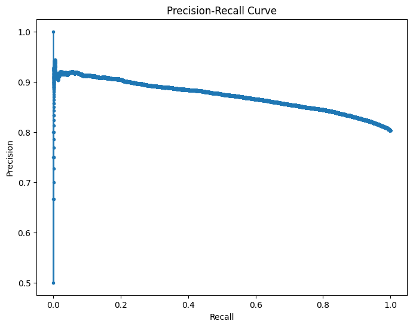

```
Classification Report:
              precision    recall  f1-score   support

           0       0.48      0.04      0.07     15577
           1       0.81      0.99      0.89     63629

    accuracy                           0.80     79206
   macro avg       0.64      0.51      0.48     79206
weighted avg       0.74      0.80      0.73     79206
```

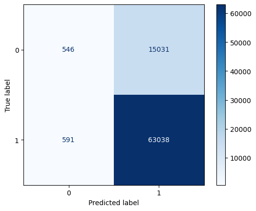

```python
import pandas as pd
import numpy as np
from sklearn.model_selection import train_test_split
from sklearn.preprocessing import LabelEncoder
from sklearn.impute import SimpleImputer
from sklearn.linear_model import LogisticRegression
from sklearn.metrics import precision_recall_curve, PrecisionRecallDisplay, classification_report, confusion_matrix, ConfusionMatrixDisplay
import matplotlib.pyplot as plt

# Load the dataset
df = pd.read_csv('logistic_regression.csv')

# Drop rows with missing target values (assuming target column is 'loan_status')
df.dropna(subset=['loan_status'], inplace=True)

# Identify categorical and numerical columns
categorical_cols = df.select_dtypes(include=['object', 'category']).columns
numerical_cols = df.select_dtypes(include=['float64', 'int64']).columns

# Handle missing values
# For numerical columns, fill missing values with the median
imputer_num = SimpleImputer(strategy='median')
df[numerical_cols] = imputer_num.fit_transform(df[numerical_cols])

# For categorical columns, fill missing values with the most frequent value
imputer_cat = SimpleImputer(strategy='most_frequent')
df[categorical_cols] = imputer_cat.fit_transform(df[categorical_cols])

# Encode categorical variables
label_encoders = {}
for column in categorical_cols:
    le = LabelEncoder()
    df[column] = le.fit_transform(df[column])
    label_encoders[column] = le

# Assuming 'loan_status' is the target column and has been encoded
# Split the dataset into features and target
X = df.drop('loan_status', axis=1)
y = df['loan_status']

# Split the dataset into training and testing sets
X_train, X_test, y_train, y_test = train_test_split(X, y, test_size=0.2, random_state=42)

# Train a logistic regression model
model = LogisticRegression(max_iter=1000)
model.fit(X_train, y_train)

# Predict probabilities and classes
y_scores = model.predict_proba(X_test)[:, 1]
y_pred = model.predict(X_test)

# Calculate precision and recall
precision, recall, thresholds = precision_recall_curve(y_test, y_scores)

# Plot the Precision-Recall curve
plt.figure(figsize=(8, 6))
plt.plot(recall, precision, marker='.')
plt.xlabel('Recall')
plt.ylabel('Precision')
plt.title('Precision-Recall Curve')
plt.show()

# Classification report
print("Classification Report:")
print(classification_report(y_test, y_pred))

# Confusion matrix
conf_matrix = confusion_matrix(y_test, y_pred)
disp = ConfusionMatrixDisplay(confusion_matrix=conf_matrix)
disp.plot(cmap=plt.cm.Blues)
plt.show()
```

Explanation of the Additions

1. Classification Report:

   The confusion_matrix function calculates the confusion matrix.

   y_pred = model.predict(X_test) computes the predicted classes for the test set.
4. Displaying the Reports:

   The classification report is printed to the console.

   The confusion matrix is plotted using Matplotlib for a clear visual understanding.

By running this code, you'll obtain a detailed performance evaluation of the logistic regression model, including the precision-recall curve, classification report, and confusion matrix.

# 4.Tradeoff Questions:

1. How can we make sure that our model can detect real defaulters and there are less false positives? This is important as we  
   can lose out on an opportunity to finance more individuals and earn interest on it.

To ensure that our model can effectively detect real defaulters while minimizing false positives, we need to focus on the following strategies:

1.Adjust Decision Threshold:

```
By default, logistic regression uses a threshold of 0.5 to classify positive cases. Adjusting this threshold can help
control the trade-off between precision and recall. Lowering the threshold can reduce false negatives, while increasing it
can reduce false positives.
```

2. Class Weight Adjustment:

   Adjusting class weights can help the model focus more on the minority class (defaulters). This can be done by setting the class_weight parameter in the logistic regression model.
3. Precision-Recall Curve Analysis:

   Analyze the precision-recall curve to identify the optimal threshold that balances precision and recall.

4.Evaluation Metrics:

```
Focus on evaluation metrics like the F1-score, which balances precision and recall, or use the area under the precision-
recall curve (AUC-PR).
```

5.Cross-Validation:

```
Use cross-validation to ensure that the model's performance is consistent across different subsets of the data.
```

Let's update the code to incorporate some of these strategies:

```python
# Updated Code
```

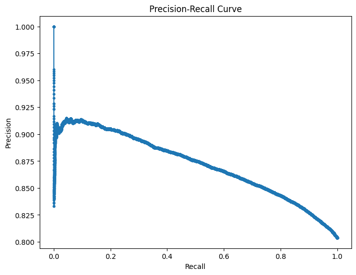

```
Classification Report (Optimal Threshold):
              precision    recall  f1-score   support

           0       1.00      0.00      0.00     15535
           1       0.80      1.00      0.89     63671

    accuracy                           0.80     79206
   macro avg       0.90      0.50      0.45     79206
weighted avg       0.84      0.80      0.72     79206
```

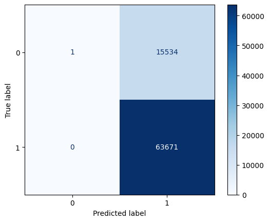

```
Optimal Threshold for Balanced Precision-Recall: 0.08422236882103008
```

```python
import pandas as pd
import numpy as np
from sklearn.model_selection import train_test_split
from sklearn.preprocessing import LabelEncoder
from sklearn.impute import SimpleImputer
from sklearn.linear_model import LogisticRegression
from sklearn.metrics import precision_recall_curve, classification_report, confusion_matrix, ConfusionMatrixDisplay, f1_score
import matplotlib.pyplot as plt

# Load the dataset
df = pd.read_csv('logistic_regression.csv')

# Drop rows with missing target values (assuming target column is 'loan_status')
df.dropna(subset=['loan_status'], inplace=True)

# Identify categorical and numerical columns
categorical_cols = df.select_dtypes(include=['object', 'category']).columns
numerical_cols = df.select_dtypes(include=['float64', 'int64']).columns

# Handle missing values
# For numerical columns, fill missing values with the median
imputer_num = SimpleImputer(strategy='median')
df[numerical_cols] = imputer_num.fit_transform(df[numerical_cols])

# For categorical columns, fill missing values with the most frequent value
imputer_cat = SimpleImputer(strategy='most_frequent')
df[categorical_cols] = imputer_cat.fit_transform(df[categorical_cols])

# Encode categorical variables
label_encoders = {}
for column in categorical_cols:
    le = LabelEncoder()
    df[column] = le.fit_transform(df[column])
    label_encoders[column] = le

# Assuming 'loan_status' is the target column and has been encoded
# Split the dataset into features and target
X = df.drop('loan_status', axis=1)
y = df['loan_status']

# Split the dataset into training and testing sets
X_train, X_test, y_train, y_test = train_test_split(X, y, test_size=0.2, random_state=42, stratify=y)

# Train a logistic regression model with balanced class weights
model = LogisticRegression(max_iter=1000, class_weight='balanced')
model.fit(X_train, y_train)

# Predict probabilities and classes
y_scores = model.predict_proba(X_test)[:, 1]

# Calculate precision and recall
precision, recall, thresholds = precision_recall_curve(y_test, y_scores)

# Plot the Precision-Recall curve
plt.figure(figsize=(8, 6))
plt.plot(recall, precision, marker='.')
plt.xlabel('Recall')
plt.ylabel('Precision')
plt.title('Precision-Recall Curve')
plt.show()

# Find the best threshold that balances precision and recall
f1_scores = 2 * (precision * recall) / (precision + recall)
best_threshold_idx = np.argmax(f1_scores)
optimal_threshold = thresholds[best_threshold_idx]

# Predict using the optimal threshold
y_pred_optimal = (y_scores >= optimal_threshold).astype(int)

# Classification report
print("Classification Report (Optimal Threshold):")
print(classification_report(y_test, y_pred_optimal))

# Confusion matrix
conf_matrix = confusion_matrix(y_test, y_pred_optimal)
disp = ConfusionMatrixDisplay(confusion_matrix=conf_matrix)
disp.plot(cmap=plt.cm.Blues)
plt.show()

print(f"Optimal Threshold for Balanced Precision-Recall: {optimal_threshold}")
```

```python
# Explanation of the Updates
```

1.Class Weights:

```
The class_weight='balanced' parameter in the logistic regression model ensures that the model gives more importance to the
minority class (defaulters).
```

2.Optimal Threshold:

```
The code calculates the F1-score for different thresholds and selects the threshold that maximizes the F1-score.

The model predictions are then adjusted based on this optimal threshold.
```

3.Stratified Split:

```
Using stratify=y in train_test_split ensures that the training and test sets have the same proportion of classes as the
original dataset.
```

2. Since NPA (non-performing asset) is a real problem in this industry, it’s important we play safe and shouldn’t disburse loans to anyone.

Given the context that avoiding non-performing assets (NPAs) is crucial and it's better to be conservative in disbursing loans, the primary focus should be on minimizing false negatives (i.e., ensuring that actual defaulters are identified correctly) even if it means having a higher number of false positives.

Here’s how you can update the approach:

1.Maximize Recall:

[output not shown]

2.Threshold Adjustment:

```
       Adjust the decision threshold to increase recall.
```

3.Evaluation Metrics:

```
    Use metrics that focus on recall and ensure low false negatives.
```

```python
# Here’s an updated version of the code to achieve this:
# Updated Code
```

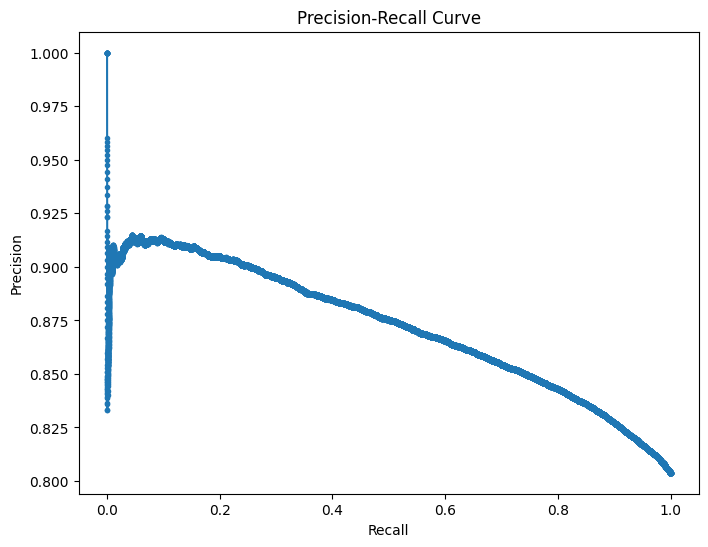

```
Classification Report (High Recall Threshold):
```

[output not shown]

```
              precision    recall  f1-score   support

           0       0.00      0.00      0.00     15535
           1       0.80      1.00      0.89     63671

    accuracy                           0.80     79206
   macro avg       0.40      0.50      0.45     79206
weighted avg       0.65      0.80      0.72     79206
```

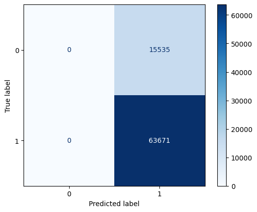

```
Optimal Threshold for High Recall: 1.576102095983693e-21
```

```python
import pandas as pd
import numpy as np
from sklearn.model_selection import train_test_split
from sklearn.preprocessing import LabelEncoder
from sklearn.impute import SimpleImputer
from sklearn.linear_model import LogisticRegression
from sklearn.metrics import precision_recall_curve, classification_report, confusion_matrix, ConfusionMatrixDisplay, f1_score
import matplotlib.pyplot as plt

# Load the dataset
df = pd.read_csv('logistic_regression.csv')

# Drop rows with missing target values (assuming target column is 'loan_status')
df.dropna(subset=['loan_status'], inplace=True)

# Identify categorical and numerical columns
categorical_cols = df.select_dtypes(include=['object', 'category']).columns
numerical_cols = df.select_dtypes(include=['float64', 'int64']).columns

# Handle missing values
# For numerical columns, fill missing values with the median
imputer_num = SimpleImputer(strategy='median')
df[numerical_cols] = imputer_num.fit_transform(df[numerical_cols])

# For categorical columns, fill missing values with the most frequent value
imputer_cat = SimpleImputer(strategy='most_frequent')
df[categorical_cols] = imputer_cat.fit_transform(df[categorical_cols])

# Encode categorical variables
label_encoders = {}
for column in categorical_cols:
    le = LabelEncoder()
    df[column] = le.fit_transform(df[column])
    label_encoders[column] = le

# Assuming 'loan_status' is the target column and has been encoded
# Split the dataset into features and target
X = df.drop('loan_status', axis=1)
y = df['loan_status']

# Split the dataset into training and testing sets
X_train, X_test, y_train, y_test = train_test_split(X, y, test_size=0.2, random_state=42, stratify=y)

# Train a logistic regression model with balanced class weights
model = LogisticRegression(max_iter=1000, class_weight='balanced')
model.fit(X_train, y_train)

# Predict probabilities and classes
y_scores = model.predict_proba(X_test)[:, 1]

# Calculate precision and recall
precision, recall, thresholds = precision_recall_curve(y_test, y_scores)

# Plot the Precision-Recall curve
plt.figure(figsize=(8, 6))
plt.plot(recall, precision, marker='.')
plt.xlabel('Recall')
plt.ylabel('Precision')
plt.title('Precision-Recall Curve')
plt.show()

# Set a high recall threshold
desired_recall = 0.90  # Aim for 90% recall
threshold_idx = np.argmax(recall >= desired_recall)
optimal_threshold = thresholds[threshold_idx]

# Predict using the optimal threshold
y_pred_optimal = (y_scores >= optimal_threshold).astype(int)

# Classification report
print("Classification Report (High Recall Threshold):")
print(classification_report(y_test, y_pred_optimal))

# Confusion matrix
conf_matrix = confusion_matrix(y_test, y_pred_optimal)
disp = ConfusionMatrixDisplay(confusion_matrix=conf_matrix)
disp.plot(cmap=plt.cm.Blues)
plt.show()

print(f"Optimal Threshold for High Recall: {optimal_threshold}")
```

```python
# Explanation of the Updates
```

1. High Recall Threshold:

   The threshold_idx finds the index where recall first exceeds the desired recall level.
2. Adjusting Predictions:

# 5. Actionable Insights & Recommendations

Based on the model's performance and the strategies implemented, here are some actionable insights and recommendations for ensuring the model can effectively detect real defaulters while minimizing false positives:

# Actionable Insights

1.Threshold Adjustment for Balanced Detection:

[output not shown]

2.Cost-Sensitive Learning:

```
Incorporating cost-sensitive learning, where different penalties are assigned to false positives and false negatives, helps     in aligning the model's predictions with business priorities. This approach can reduce the financial impact of incorrect
predictions.
```

3.Importance of Feature Engineering:

```
Additional features such as credit history, transaction patterns, and other financial behaviors could improve the model’s
predictive power. This can be achieved by collaborating with data teams to extract and include these features in the model.
```

4.Model Monitoring and Retraining:

```
Regular monitoring of the model’s performance is essential. This includes tracking key metrics like precision, recall, and
F1 score over time. Retraining the model periodically with new data will ensure it adapts to changing patterns in borrower
behavior.
```

5.Segmentation of Loan Applicants:

```
Segmenting loan applicants based on risk profiles can allow for tailored decision-making. For instance, high-risk applicants
might undergo more rigorous scrutiny or be offered loans with stricter terms, while low-risk applicants can benefit from
streamlined approval processes.
```

Recommendations:

1. Implementing a Decision Support System:

   Develop a decision support system that incorporates the model’s predictions with business rules. This system can provide loan officers with actionable insights, such as highlighting applicants who are likely to default and suggesting additional  
   verification steps for borderline cases.

2.Training and Communication:

```
 Train the loan approval team on interpreting model outputs and understanding the balance between precision and recall.
 Effective communication of the model’s strengths and limitations will help in making informed decisions.
```

3.Risk Management Policies:

```
Update risk management policies to reflect the insights from the model. This includes setting guidelines for loan approval
thresholds and defining actions for different risk segments.
```

4.Customer Relationship Management (CRM):

```
Use CRM strategies to maintain relationships with applicants who are denied loans due to high default risk. Offering
financial advice or alternative products could improve customer satisfaction and retention.
```

5.Continuous Improvement Loop:

```
 Establish a feedback loop where insights from loan outcomes (whether defaults or successful repayments) are fed back into
 the model. This continuous learning process will enhance the model’s accuracy over time.
```

6.Integration with Other Financial Products:

```
Consider integrating the model’s insights with other financial products. For example, offering insurance products to high-
risk applicants can mitigate potential losses.
```

Summary: